# PHDEXAM_AKANKSHA_78_EDA

### BROADBAND OUTAGE DETECTION

##### Problem statement is on Broadband Outage Detection ,where we need to create a machine learning model using the metrices tracked by the company that will be able to predict the `outage_duration` so that the company can better handle outages and improve customer satisfaction and therefore reduce customer churn.

Metrices are :

1)broadband_data( There are `10 different types` of broadbands that are observed in the dataset )

2)outage_data(There are `5` different `outage_type`'s recorded in the dataset. )

3)report_data(For each event `id` there are `log_report_type` and `volume` columns are recorded. )

4)server_data(a record of the `transit_server_type` that is stored in the dataset )

5)train_data(which includes unique event id for each observation of the `outage_duration` in a particular `area_code` )

#### SETTING THE DIRECTORY

```python
import os
os.chdir("C:/Users/Akanksha Dash/Downloads/20200628_CSE9099c_PHD_Dataset-1593175193570/data")
```

#### IMPORTING LIBRARIES

```python
import pandas as pd
import numpy as np

from sklearn import preprocessing
from sklearn.impute import SimpleImputer
from sklearn.compose import ColumnTransformer

from sklearn.preprocessing import StandardScaler
from sklearn.preprocessing import OneHotEncoder
from sklearn.model_selection import train_test_split
from sklearn.pipeline import Pipeline
from sklearn.model_selection import GridSearchCV, RandomizedSearchCV

from sklearn.svm import SVC
from sklearn.linear_model import LogisticRegression
from sklearn.metrics import confusion_matrix
from sklearn.tree import DecisionTreeClassifier
from sklearn.ensemble import RandomForestClassifier
from sklearn.model_selection import StratifiedKFold
from xgboost import XGBClassifier
from imblearn.over_sampling import SMOTE

import matplotlib.pyplot as plt
import seaborn as sns
from sklearn.metrics import accuracy_score, recall_score, precision_score,classification_report

import warnings
warnings.filterwarnings('ignore')
```

#### Reading the 5 CSV files

```python
#Reading the CSV file
trdata = pd.read_csv("train_data.csv", sep=',', header=0,
                        na_values='unknown')
srvdata=pd.read_csv("server_data.csv", sep=',', header=0,
                        na_values='unknown')
repdata=pd.read_csv("report_data.csv", sep=',', header=0,
                        na_values='unknown')
outdata=pd.read_csv("outage_data.csv", sep=',', header=0,
                        na_values='unknown')
brddata=pd.read_csv("broadband_data.csv", sep=',', header=0,
                        na_values='unknown')
```

```python
trdata.head(3)
```

|  | id | area_code | outage_duration |
| --- | --- | --- | --- |
| 0 | 13366 | area_415 | 1 |
| 1 | 6783 | area_474 | 0 |
| 2 | 9519 | area_931 | 1 |

```python
srvdata.head(3)
```

|  | id | transit_server_type |
| --- | --- | --- |
| 0 | 6597 | transit_server_type_11 |
| 1 | 8011 | transit_server_type_15 |
| 2 | 2597 | transit_server_type_15 |

```python
repdata.head(3)
```

|  | id | log_report_type | volume |
| --- | --- | --- | --- |
| 0 | 6597 | log_report_type_68 | 6 |
| 1 | 8011 | log_report_type_68 | 7 |
| 2 | 2597 | log_report_type_68 | 1 |

```python
outdata.head(3)
```

|  | id | outage_type |
| --- | --- | --- |
| 0 | 6597 | outage_type_2 |
| 1 | 8011 | outage_type_2 |
| 2 | 2597 | outage_type_2 |

```python
brddata.head(3)
```

|  | id | broadband_type |
| --- | --- | --- |
| 0 | 6597 | broadband_type_8 |
| 1 | 8011 | broadband_type_8 |
| 2 | 2597 | broadband_type_8 |

#### MERGING THE DATAS

```python
#MERGING THE DATA TO WORK ON
train_1 = trdata.merge(brddata, how = 'left', left_on='id', right_on='id')
train_2 = train_1.merge(outdata, how = 'left', left_on='id', right_on='id')
train_3 = train_2.merge(repdata, how = 'left', left_on='id', right_on='id')
traindata = train_3.merge(srvdata, how = 'left', left_on='id', right_on='id')
```

```python
#1st merge shape
train_1.shape
```

```
(6754, 4)
```

```python
#2nd merge shape
train_2.shape
```

```
(6754, 5)
```

```python
#3rd merge shape
train_3.shape
```

```
(22679, 7)
```

```python
print("Shape of merged Data set :\n\n",traindata.shape,"\n")
```

```
Shape of merged Data set :

 (48973, 8)
```

#### REMOVING THE DUPLICATES

```python
traindata.drop_duplicates(subset= 'id', keep= 'first', inplace = True)
```

```python
print("Shape of Data set after removing duplicates:\n\n",traindata.shape,"\n")
```

```
Shape of Data set after removing duplicates:

 (5904, 8)
```

```python
#Creating a copy
train_data=traindata.copy()
```

#### EXPLORATORY DATA ANALYSIS (EDA)

```python
print("Dimension of our final Dataset :\n\n",train_data.shape,"\n")
```

```
Dimension of our final Dataset :

 (5904, 8)
```

As shape tells us the dimension, we have 5904 rows and 8 columns . Also checking the dimension after creating a copy

```python
# Let's check the names of the columns?
print(list(train_data.columns))
```

```
['id', 'area_code', 'outage_duration', 'broadband_type', 'outage_type', 'log_report_type', 'volume', 'transit_server_type']
```

```python
train_data.columns
```

```
Index(['id', 'area_code', 'outage_duration', 'broadband_type', 'outage_type',
       'log_report_type', 'volume', 'transit_server_type'],
      dtype='object')
```

```python
#Displays the types of data we have in train dataset
train_data.dtypes
```

```
id                      int64
area_code              object
outage_duration         int64
broadband_type         object
outage_type            object
log_report_type        object
volume                  int64
transit_server_type    object
dtype: object
```

```python
#Displays each of the column along with its type and the memory used by the data
train_data.info()
```

```
<class 'pandas.core.frame.DataFrame'>
Int64Index: 5904 entries, 0 to 48971
Data columns (total 8 columns):
id                     5904 non-null int64
area_code              5904 non-null object
outage_duration        5904 non-null int64
broadband_type         5904 non-null object
outage_type            5904 non-null object
log_report_type        5904 non-null object
volume                 5904 non-null int64
transit_server_type    5904 non-null object
dtypes: int64(3), object(5)
memory usage: 415.1+ KB
```

```python
#Displays stastical information about each of the columns eg. count, frequency of occurance of a value etc
train_data.describe()  #Numerical
```

|  | id | outage_duration | volume |
| --- | --- | --- | --- |
| count | 5904.000000 | 5904.000000 | 5904.000000 |
| mean | 9323.841972 | 0.450203 | 8.528455 |
| std | 5338.654942 | 0.666642 | 22.752851 |
| min | 1.000000 | 0.000000 | 1.000000 |
| 25% | 4763.500000 | 0.000000 | 1.000000 |
| 50% | 9330.500000 | 0.000000 | 2.000000 |
| 75% | 13932.750000 | 1.000000 | 7.000000 |
| max | 18550.000000 | 2.000000 | 636.000000 |

```python
train_data.describe(include = "all") #to include both numerical and categorical
```

|  | id | area_code | outage_duration | broadband_type | outage_type | log_report_type | volume | transit_server_type |
| --- | --- | --- | --- | --- | --- | --- | --- | --- |
| count | 5904.000000 | 5904 | 5904.000000 | 5904 | 5904 | 5904 | 5904.000000 | 5904 |
| unique | NaN | 876 | NaN | 9 | 5 | 213 | NaN | 44 |
| top | NaN | area_821 | NaN | broadband_type_8 | outage_type_2 | log_report_type_312 | NaN | transit_server_type_11 |
| freq | NaN | 67 | NaN | 2882 | 2875 | 580 | NaN | 1820 |
| mean | 9323.841972 | NaN | 0.450203 | NaN | NaN | NaN | 8.528455 | NaN |
| std | 5338.654942 | NaN | 0.666642 | NaN | NaN | NaN | 22.752851 | NaN |
| min | 1.000000 | NaN | 0.000000 | NaN | NaN | NaN | 1.000000 | NaN |
| 25% | 4763.500000 | NaN | 0.000000 | NaN | NaN | NaN | 1.000000 | NaN |
| 50% | 9330.500000 | NaN | 0.000000 | NaN | NaN | NaN | 2.000000 | NaN |
| 75% | 13932.750000 | NaN | 1.000000 | NaN | NaN | NaN | 7.000000 | NaN |
| max | 18550.000000 | NaN | 2.000000 | NaN | NaN | NaN | 636.000000 | NaN |

```python
#Checking Null values
total = train_data.isnull().sum().sort_values(ascending=False)
percent = (train_data.isnull().sum()/train_data.isnull().count()).sort_values(ascending=False)
missing_data = pd.concat([total, percent], axis=1, keys=['Total', 'Percent'])
missing_data.head(10)
```

|  | Total | Percent |
| --- | --- | --- |
| transit_server_type | 0 | 0.0 |
| volume | 0 | 0.0 |
| log_report_type | 0 | 0.0 |
| outage_type | 0 | 0.0 |
| broadband_type | 0 | 0.0 |
| outage_duration | 0 | 0.0 |
| area_code | 0 | 0.0 |
| id | 0 | 0.0 |

#### Distribution of Target variable

```python
train_data.outage_duration.value_counts()
```

```
0    3827
1    1496
2     581
Name: outage_duration, dtype: int64
```

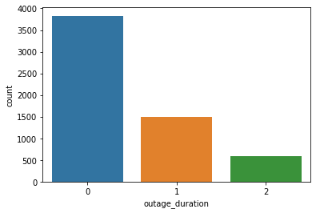

```
0    3827
1    1496
2     581
Name: outage_duration, dtype: int64
```

```python
# Plot Distribution
sns.countplot(x='outage_duration',data=train_data)
plt.show()

# What are the counts?
print(train_data.outage_duration.value_counts())
```

DRAWING TRENDS TOWARDS TARGET VARIABLE

```python
train_data.outage_duration.value_counts(normalize = True)*100
```

```
0    64.820461
1    25.338753
2     9.840786
Name: outage_duration, dtype: float64
```

```python
train_data.outage_duration.value_counts(normalize = True,dropna = False)
```

```
0    0.648205
1    0.253388
2    0.098408
Name: outage_duration, dtype: float64
```

Understanding the distribution of other variables

```python
train_data.area_code.value_counts()
```

```
area_821     67
area_1107    61
area_126     59
area_1008    57
area_734     57
             ..
area_841      1
area_436      1
area_1036     1
area_237      1
area_180      1
Name: area_code, Length: 876, dtype: int64
```

```python
train_data.transit_server_type.value_counts()
```

```
transit_server_type_11    1820
transit_server_type_35    1106
transit_server_type_15     993
transit_server_type_34     984
transit_server_type_20     275
transit_server_type_13     107
transit_server_type_54     106
transit_server_type_23      75
transit_server_type_42      58
transit_server_type_44      56
transit_server_type_14      42
transit_server_type_22      32
transit_server_type_21      31
transit_server_type_43      27
transit_server_type_10      26
transit_server_type_50      21
transit_server_type_18      15
transit_server_type_30      14
transit_server_type_24      13
transit_server_type_32      12
transit_server_type_47      11
transit_server_type_26       9
transit_server_type_40       7
transit_server_type_46       6
transit_server_type_29       6
transit_server_type_27       5
transit_server_type_2        5
transit_server_type_5        5
transit_server_type_7        5
transit_server_type_38       5
transit_server_type_6        4
transit_server_type_8        3
transit_server_type_31       3
transit_server_type_28       3
transit_server_type_45       3
transit_server_type_51       2
transit_server_type_39       2
transit_server_type_36       1
transit_server_type_25       1
transit_server_type_3        1
transit_server_type_49       1
transit_server_type_9        1
transit_server_type_12       1
transit_server_type_48       1
Name: transit_server_type, dtype: int64
```

```python
print(train_data.outage_type.value_counts())
```

```
outage_type_2    2875
outage_type_1    2700
outage_type_4     306
outage_type_5      19
outage_type_3       4
Name: outage_type, dtype: int64
```

```python
train_data.log_report_type.value_counts()
```

```
log_report_type_312    580
log_report_type_82     495
log_report_type_232    463
log_report_type_203    308
log_report_type_54     235
                      ...
log_report_type_236      1
log_report_type_348      1
log_report_type_330      1
log_report_type_245      1
log_report_type_292      1
Name: log_report_type, Length: 213, dtype: int64
```

```python
print(train_data.groupby('volume').mean())
```

```
                  id  outage_duration
volume
1        9384.400913         0.410502
2        9439.679449         0.424779
3        9066.563510         0.360277
4        9828.411594         0.510145
5        8885.803922         0.426471
...              ...              ...
283      9115.000000         0.000000
312       812.000000         0.000000
334      5558.000000         0.000000
451     17078.000000         0.000000
636      1456.000000         0.000000

[139 rows x 2 columns]
```

#### DATA VISUALISATION

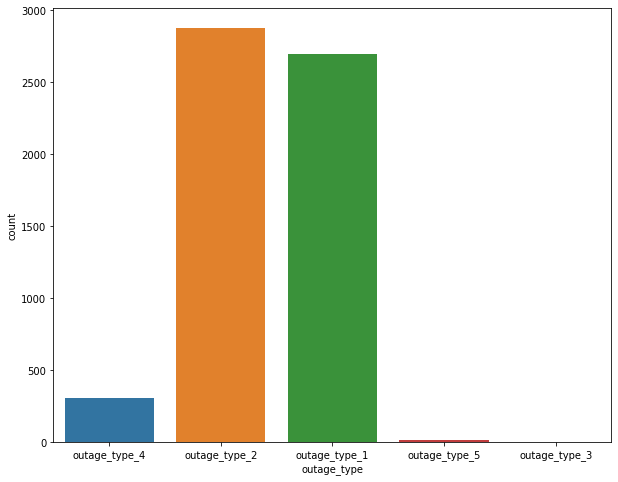

```python
## COUNT PLOT FOR OUTAGE TYPE

plt.figure(figsize = (10,8))
sns.countplot(train_data['outage_type'])
plt.show()
```

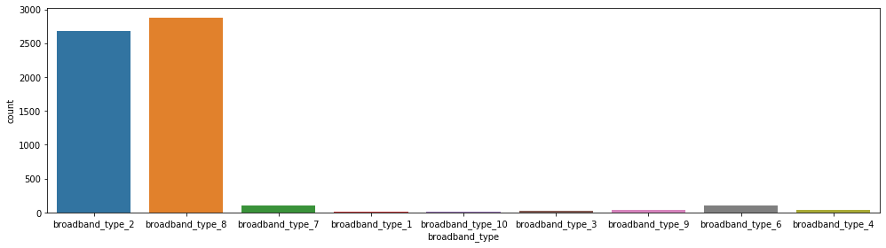

```python
#count plot for Broadband type

plt.figure(figsize = (14,4))
sns.countplot(train_data['broadband_type'])
plt.tight_layout()
plt.show()
```

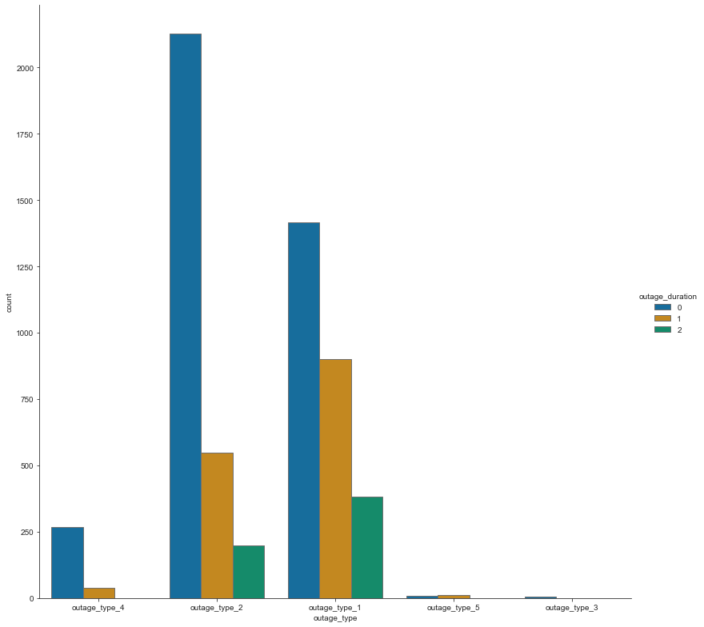

```python
#cat plot for outage type w.r.t outage_duration
sns.set_style("ticks")
sns.catplot(x="outage_type", hue="outage_duration", kind="count",height=11,
            palette="colorblind", edgecolor=".44",
            data=train_data);
```

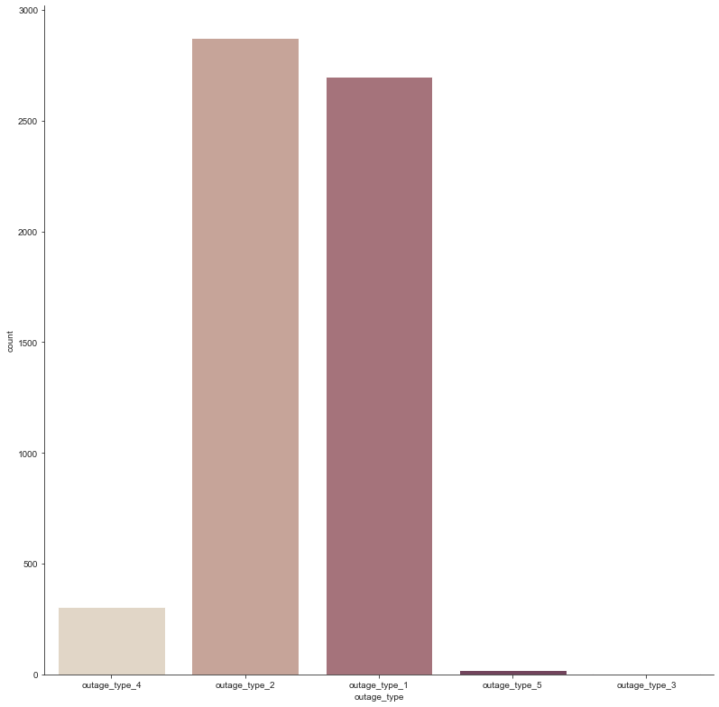

```python
#catplot for outage_type
sns.catplot(x="outage_type", kind="count", palette="ch:.25",height=11, data=train_data);
```

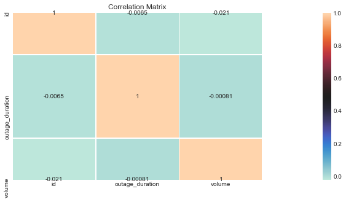

```python
#plotting the correlation matrix
plt.style.use('seaborn-dark')
plt.figure(figsize =(35,5))
sns.heatmap(train_data.corr(),vmax = 1,linewidths= 1,square= True,
           annot= True, cmap='icefire', linecolor= 'white')

plt.title('Correlation Matrix', fontsize =12)
plt.show()
```

This plot only shows the correlation between the numeric columns. To see the complete correlation matrix we would have to convert the categorical columns to ints using label encoding etc and then visualize the correlation matrix again.

##### Answering questions from the operations team:

The operations team at ‘India Broadband’ has asked you the following questions

1) Which areas are most prone to long outage durations?

2) Which broadband types are suspect of long outage durations?

3) Any other recommendations to improve the detection of outage durations.

ANSWER TO THE FIRST QUESTION i.e Which areas are most prone to long outage durations?

```python
#approach 1
long_outage = train_data.loc[train_data.outage_duration==2,'area_code'].value_counts() # AS`2` for long outages
```

```python
long_outage
```

```
area_1100    28
area_600     27
area_1107    27
area_821     24
area_734     23
             ..
area_893      1
area_57       1
area_695      1
area_1026     1
area_33       1
Name: area_code, Length: 135, dtype: int64
```

```python
prone= train_data['outage_duration']==2
```

```python
prone= train_data[prone]
```

```python
prone.head()
```

|  | id | area_code | outage_duration | broadband_type | outage_type | log_report_type | volume | transit_server_type |
| --- | --- | --- | --- | --- | --- | --- | --- | --- |
| 17 | 4555 | area_600 | 2 | broadband_type_8 | outage_type_2 | log_report_type_82 | 30 | transit_server_type_15 |
| 79 | 1373 | area_962 | 2 | broadband_type_8 | outage_type_1 | log_report_type_203 | 16 | transit_server_type_15 |
| 117 | 4209 | area_1086 | 2 | broadband_type_8 | outage_type_2 | log_report_type_82 | 23 | transit_server_type_15 |
| 157 | 8984 | area_976 | 2 | broadband_type_8 | outage_type_2 | log_report_type_82 | 40 | transit_server_type_15 |
| 163 | 14361 | area_704 | 2 | broadband_type_8 | outage_type_1 | log_report_type_80 | 5 | transit_server_type_15 |

```
area_1100    28
area_600     27
area_1107    27
area_821     24
area_734     23
area_704     19
area_1019    18
area_810     18
Name: area_code, dtype: int64
```

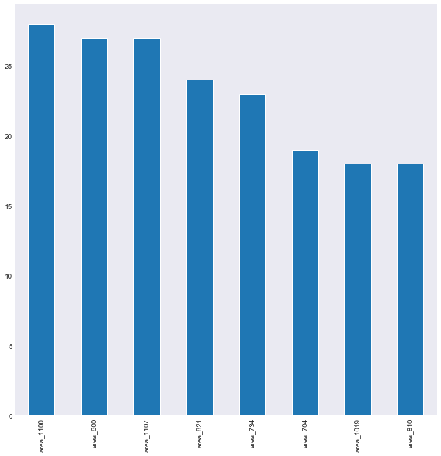

```python
count=prone.area_code.value_counts()
count.head(8).plot(kind='bar',figsize=(11,11))
count.head(8)
```

ANS 1 : From above we observe that 'area_1100' is prone to long outage duration

```python
#approach 2
Agg=train_data[['id','area_code','outage_duration']].groupby(['area_code','outage_duration']).agg('count').reset_index().rename(columns={'id':'count'})

Agg=Agg.sort_values(by=['count'],ascending=False)

ans=Agg[Agg['outage_duration']==2]

ans1=ans.reset_index()
ans1
del ans1['index']
ans1["cumpercentage"] = ans1["count"].cumsum()/ans1["count"].sum()*100
ans1
```

|  | area_code | outage_duration | count | cumpercentage |
| --- | --- | --- | --- | --- |
| 0 | area_1100 | 2 | 28 | 4.819277 |
| 1 | area_600 | 2 | 27 | 9.466437 |
| 2 | area_1107 | 2 | 27 | 14.113597 |
| 3 | area_821 | 2 | 24 | 18.244406 |
| 4 | area_734 | 2 | 23 | 22.203098 |
| ... | ... | ... | ... | ... |
| 130 | area_1026 | 2 | 1 | 99.311532 |
| 131 | area_724 | 2 | 1 | 99.483649 |
| 132 | area_33 | 2 | 1 | 99.655766 |
| 133 | area_73 | 2 | 1 | 99.827883 |
| 134 | area_1024 | 2 | 1 | 100.000000 |

135 rows × 4 columns

ANSWER TO THE SECOND QUESTION i.e 'Which broadband types are suspect of long outage durations? '

```
outage_duration       0    1    2
broadband_type
broadband_type_1      4    5    5
broadband_type_10     8    4    1
broadband_type_2   2166  454   62
broadband_type_3     11   14    1
broadband_type_4     23   20    1
broadband_type_6     34   60    8
broadband_type_7     54   41    4
broadband_type_8   1505  879  498
broadband_type_9     22   19    1
```

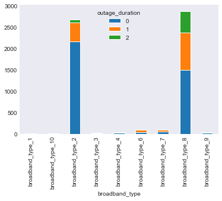

```python
#1st APPROACH
suspects=pd.crosstab(train_data['broadband_type'],train_data['outage_duration'])
print(suspects)
suspects.plot.bar(stacked =True)
plt.show()
```

ANSWER 2:

INSIGHTS:

As 2 is for 'long outage' from above observation broadband type 8 has begged the position for suspect by 498 counts

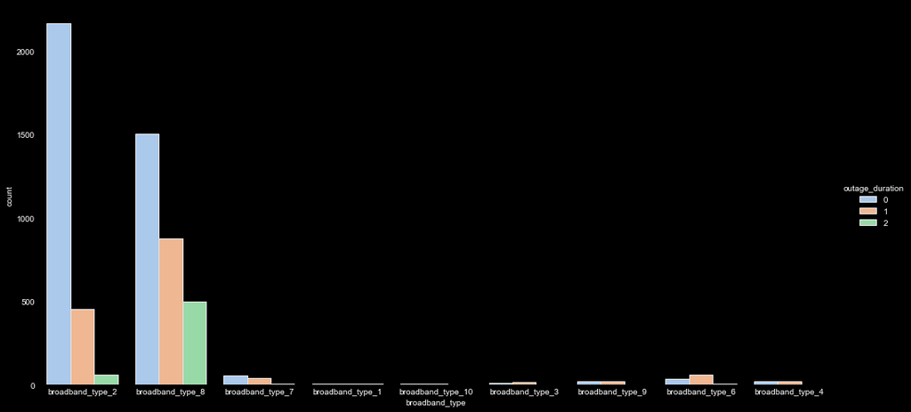

```python
#2nd approach
plt.style.use('dark_background')
sns.catplot(x="broadband_type", hue="outage_duration", kind="count",height=7,aspect=2,
            palette="pastel", edgecolor=".9",
            data=train_data);
```

```python
#3rd Approach
ans2=train_data.groupby(['broadband_type']).sum()
```

```python
ans2
```

| broadband_type | id | outage_duration | volume |
| --- | --- | --- | --- |
| broadband_type_1 | 150380 | 15 | 97 |
| broadband_type_10 | 86070 | 6 | 23 |
| broadband_type_2 | 25027078 | 578 | 24954 |
| broadband_type_3 | 301850 | 16 | 69 |
| broadband_type_4 | 371267 | 22 | 167 |
| broadband_type_6 | 934159 | 76 | 201 |
| broadband_type_7 | 956429 | 49 | 269 |
| broadband_type_8 | 26825297 | 1875 | 24500 |
| broadband_type_9 | 395433 | 21 | 72 |

```python
ans_2=ans2.drop(['id','volume'], axis=1).sort_values('outage_duration', ascending=False)
```

```python
ans_2
```

| broadband_type | outage_duration |
| --- | --- |
| broadband_type_8 | 1875 |
| broadband_type_2 | 578 |
| broadband_type_6 | 76 |
| broadband_type_7 | 49 |
| broadband_type_4 | 22 |
| broadband_type_9 | 21 |
| broadband_type_3 | 16 |
| broadband_type_1 | 15 |
| broadband_type_10 | 6 |

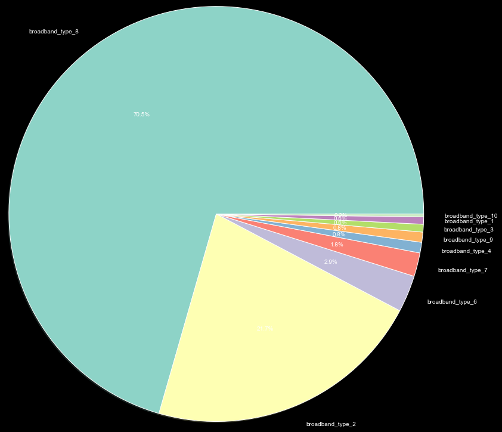

```python
#4th approach
plt.style.use('dark_background')
label_list1 = ans_2.index
plt.pie(ans_2['outage_duration'],labels=label_list1,autopct ='%1.1f%%',radius=4, shadow = True)
plt.show()
```

```python
#3RD ANSWER - AT THIS MOMENT IT WON'T JUSTIFY TO THE COMPANY BY GIVING ANY RECOMMENDATIONS TO IMPROVE THE DETECTION OF OUTAGE DURATION
#AFTER MODELING AND UNDERSTANDING THE FEATURE IMPORTANCE I CAN BE IN A SITUATION TO RECOMMEND
```